# Categorical

Cecile Bester

2024-04-29

# Required pacakges

```r
library(RcmdrMisc)
```

```r
library(ggplot2)
library(ROCR)
library(car)
```

# the allSubsets() function

```r
allSubsets.LogistReg <- function(data,y.name="Y",perf.measure=c("AIC","BIC")){

  Cols <- names(data)
  Cols <- Cols[! Cols %in% y.name]
  n <- length(Cols)

  id <- unlist(
    lapply(1:n,
           function(i)combn(1:n,i,simplify=F)
    )
    ,recursive=F)

  Formulas <- sapply(id,function(i)
    paste(y.name,"~",paste(Cols[i],collapse="+"))
  )

  result.mat <- matrix(0,nrow=length(Formulas),3)
  result.mat[,1] <- Formulas


  #get all AIC's

  for(i in 1:length(Formulas)){result.mat[i,2] <- AIC(glm(as.formula(Formulas[i]),
                                                         data=data,family=binomial))}
  #get all BIC's

  for(i in 1:length(Formulas)){result.mat[i,3] <- BIC(glm(as.formula(Formulas[i]),
                                                         data=data,family=binomial))}




  colnames(result.mat) <- c("Model","AIC","BIC")



  final.output <- data.frame(result.mat[order(result.mat[,perf.measure],decreasing=T),])

  return(final.output)

}
```

# Calculate the gini coefficient for a binary classifier

```r
calcGini <- function(model,Y){

  if("ROCR" %in% installed.packages()[,"Package"] == "FALSE") stop("ROCR is not installed")

  library(ROCR)

  probs <- predict(model,type="response")
  pred <- prediction(probs,Y)
  perf <- performance(pred,'auc')
  gini <- abs(1-2*attr(perf,'y.values')[[1]])
  return(gini)
}
```

# ROC Curve

```r
performance <- function(prediction.obj, measure,
                        x.measure="cutoff", ...) {

    ## define the needed environments
    envir.list <- .define.environments()
    long.unit.names <- envir.list$long.unit.names
    function.names <- envir.list$function.names
    obligatory.x.axis <- envir.list$obligatory.x.axis
    optional.arguments <- envir.list$optional.arguments
    default.values <- envir.list$default.values

    ## abort in case of misuse
    if (class(prediction.obj) != 'prediction' ||
        !exists(measure, where=long.unit.names, inherits=FALSE) ||
        !exists(x.measure, where=long.unit.names, inherits=FALSE)) {
      stop(paste("Wrong argument types: First argument must be of type",
                 "'prediction'; second and optional third argument must",
                 "be available performance measures!"))
    }

    ## abort, if attempt is made to use a measure that has an obligatory
    ## x.axis as the x.measure (cannot be combined)
    if (exists( x.measure, where=obligatory.x.axis, inherits=FALSE )) {
        message <- paste("The performance measure",
                         x.measure,
                         "can only be used as 'measure', because it has",
                         "the following obligatory 'x.measure':\n",
                         get( x.measure, envir=obligatory.x.axis))
        stop(message)
    }

    ## if measure is a performance measure with obligatory x.axis, then
    ## enforce this axis:
    if (exists( measure, where=obligatory.x.axis, inherits=FALSE )) {
        x.measure <- get( measure, envir=obligatory.x.axis )
    }

    if (x.measure == "cutoff" ||
        exists( measure, where=obligatory.x.axis, inherits=FALSE )) {

        ## fetch from '...' any optional arguments for the performance
        ## measure at hand that are given, otherwise fill up the default values
        optional.args <- list(...)
        argnames <- c()
        if ( exists( measure, where=optional.arguments, inherits=FALSE )) {
            argnames <- get( measure, envir=optional.arguments )
            default.arglist <- list()
            for (i in 1:length(argnames)) {
                default.arglist <- c(default.arglist,
                                     get(paste(measure,":",argnames[i],sep=""),
                                         envir=default.values, inherits=FALSE))
            }
            names(default.arglist) <- argnames

            for (i in 1:length(argnames)) {
                templist <- list(optional.args,
                                 default.arglist[[i]])
                names(templist) <- c('arglist', argnames[i])

                optional.args <- do.call('.farg', templist)
            }
        }
        optional.args <- .select.args( optional.args, argnames )

        ## determine function name
        function.name <- get( measure, envir=function.names )

        ## for each x-validation run, compute the requested performance measure
        x.values <- list()
        y.values <- list()
        for (i in 1:length( prediction.obj@predictions )) {
            argumentlist <- .sarg(optional.args,
                                  predictions= prediction.obj@predictions[[i]],
                                  labels= prediction.obj@labels[[i]],
                                  cutoffs= prediction.obj@cutoffs[[i]],
                                  fp= prediction.obj@fp[[i]],
                                  tp= prediction.obj@tp[[i]],
                                  fn= prediction.obj@fn[[i]],
                                  tn= prediction.obj@tn[[i]],
                                  n.pos= prediction.obj@n.pos[[i]],
                                  n.neg= prediction.obj@n.neg[[i]],
                                  n.pos.pred= prediction.obj@n.pos.pred[[i]],
                                  n.neg.pred= prediction.obj@n.neg.pred[[i]])

            ans <- do.call( function.name, argumentlist )

            if (!is.null(ans[[1]])) x.values <- c( x.values, list( ans[[1]] ))
            y.values <- c( y.values, list( ans[[2]] ))
        }

        if (! (length(x.values)==0 || length(x.values)==length(y.values)) ) {
            stop("Consistency error.")
        }

        ## create a new performance object
        return( new("performance",
                    x.name       = get( x.measure, envir=long.unit.names ),
                    y.name       = get( measure, envir=long.unit.names ),
                    alpha.name   = "none",
                    x.values     = x.values,
                    y.values     = y.values,
                    alpha.values = list() ))
    } else {
        perf.obj.1 <- performance( prediction.obj, measure=x.measure, ... )
        perf.obj.2 <- performance( prediction.obj, measure=measure, ... )
        return( .combine.performance.objects( perf.obj.1, perf.obj.2 ) )
    }
}

.combine.performance.objects <- function( p.obj.1, p.obj.2 ) {
    ## some checks for misusage (in any way, this function is
    ## only for internal use)
    if ( p.obj.1@x.name != p.obj.2@x.name ) {
        stop("Error: Objects need to have identical x axis.")
    }
    if ( p.obj.1@alpha.name != "none" || p.obj.2@alpha.name != "none") {
        stop("Error: At least one of the two objects has already been merged.")
    }
    if (length(p.obj.1@x.values) != length(p.obj.2@x.values)) {
        stop(paste("Only performance objects with identical number of",
                   "cross-validation runs can be combined."))
    }

    x.values <- list()
    x.name <- p.obj.1@y.name
    y.values <- list()
    y.name <- p.obj.2@y.name
    alpha.values <- list()
    alpha.name <- p.obj.1@x.name

    for (i in 1:length( p.obj.1@x.values )) {
        x.values.1 <- p.obj.1@x.values[[i]]
        y.values.1 <- p.obj.1@y.values[[i]]
        x.values.2 <- p.obj.2@x.values[[i]]
        y.values.2 <- p.obj.2@y.values[[i]]

        ## cutoffs of combined object = merged cutoffs of simple objects
        cutoffs <- sort( unique( c(x.values.1, x.values.2)), decreasing=TRUE )
```

```r
        ## calculate y.values at cutoffs using step function
        y.values.int.1 <- approxfun(x.values.1, y.values.1,
                                    method="constant",f=1,rule=2)(cutoffs)
        y.values.int.2 <- approxfun(x.values.2, y.values.2,
                                    method="constant",f=1,rule=2)(cutoffs)

        ## 'approxfun' ignores NA and NaN
        objs <- list( y.values.int.1, y.values.int.2)
        objs.x <- list( x.values.1, x.values.2 )
        na.cutoffs.1.bool <- is.na( y.values.1) & !is.nan( y.values.1 )
        nan.cutoffs.1.bool <- is.nan( y.values.1)
        na.cutoffs.2.bool <- is.na( y.values.2) & !is.nan( y.values.2 )
        nan.cutoffs.2.bool <- is.nan( y.values.2)
        bools <- list(na.cutoffs.1.bool, nan.cutoffs.1.bool,
                      na.cutoffs.2.bool, nan.cutoffs.2.bool)
        values <- c(NA,NaN,NA,NaN)

        for (j in 1:4) {
            for (k in which(bools[[j]])) {
                interval.max <- objs.x[[ ceiling(j/2) ]][k]
                interval.min <- -Inf
                if (k < length(objs.x[[ ceiling(j/2) ]])) {
                    interval.min <- objs.x[[ ceiling(j/2) ]][k+1]
                }
                objs[[ ceiling(j/2) ]][cutoffs <= interval.max &
                                       cutoffs > interval.min ] <- values[j]
            }
        }

        alpha.values <- c(alpha.values, list(cutoffs))
        x.values <- c(x.values, list(objs[[1]]))
        y.values <- c(y.values, list(objs[[2]]))
    }

    return( new("performance",
                x.name=x.name, y.name=y.name,
                alpha.name=alpha.name, x.values=x.values,
                y.values=y.values, alpha.values=alpha.values))
}

.define.environments <- function() {
    ## There are five environments: long.unit.names, function.names,
    ## obligatory.x.axis, optional.arguments, default.values

    ## Define long names corresponding to the measure abbreviations.
    long.unit.names <- new.env()
    assign("none","None", envir=long.unit.names)
    assign("cutoff", "Cutoff", envir=long.unit.names)
    assign("acc", "Accuracy", envir=long.unit.names)
    assign("err", "Error Rate", envir=long.unit.names)
    assign("fpr", "False positive rate", envir=long.unit.names)
    assign("tpr", "True positive rate", envir=long.unit.names)
    assign("rec", "Recall", envir=long.unit.names)
    assign("sens", "Sensitivity", envir=long.unit.names)
    assign("fnr", "False negative rate", envir=long.unit.names)
    assign("tnr", "True negative rate", envir=long.unit.names)
    assign("spec", "Specificity", envir=long.unit.names)
    assign("ppv", "Positive predictive value", envir=long.unit.names)
    assign("prec", "Precision", envir=long.unit.names)
    assign("npv", "Negative predictive value", envir=long.unit.names)
    assign("fall", "Fallout", envir=long.unit.names)
    assign("miss", "Miss", envir=long.unit.names)
    assign("pcfall", "Prediction-conditioned fallout", envir=long.unit.names)
    assign("pcmiss", "Prediction-conditioned miss", envir=long.unit.names)
    assign("rpp", "Rate of positive predictions", envir=long.unit.names)
    assign("rnp", "Rate of negative predictions", envir=long.unit.names)
    assign("auc","Area under the ROC curve", envir=long.unit.names)
    assign("cal", "Calibration error", envir=long.unit.names)
    assign("mwp", "Median window position", envir=long.unit.names)
    assign("prbe","Precision/recall break-even point", envir=long.unit.names)
    assign("rch", "ROC convex hull", envir=long.unit.names)
    assign("mxe", "Mean cross-entropy", envir=long.unit.names)
    assign("rmse","Root-mean-square error", envir=long.unit.names)
    assign("phi", "Phi correlation coefficient", envir=long.unit.names)
    assign("mat","Matthews correlation coefficient", envir=long.unit.names)
    assign("mi", "Mutual information", envir=long.unit.names)
    assign("chisq", "Chi-square test statistic", envir=long.unit.names)
    assign("odds","Odds ratio", envir=long.unit.names)
    assign("lift", "Lift value", envir=long.unit.names)
    assign("f","Precision-Recall F measure", envir=long.unit.names)
    assign("sar", "SAR", envir=long.unit.names)
    assign("ecost", "Expected cost", envir=long.unit.names)
    assign("cost", "Explicit cost", envir=long.unit.names)

    ## Define function names corresponding to the measure abbreviations.
    function.names <- new.env()
    assign("acc", ".performance.accuracy", envir=function.names)
    assign("err", ".performance.error.rate", envir=function.names)
    assign("fpr", ".performance.false.positive.rate", envir=function.names)
    assign("tpr", ".performance.true.positive.rate", envir=function.names)
    assign("rec", ".performance.true.positive.rate", envir=function.names)
    assign("sens", ".performance.true.positive.rate", envir=function.names)
    assign("fnr", ".performance.false.negative.rate", envir=function.names)
    assign("tnr", ".performance.true.negative.rate", envir=function.names)
    assign("spec", ".performance.true.negative.rate", envir=function.names)
    assign("ppv", ".performance.positive.predictive.value",
           envir=function.names)
    assign("prec", ".performance.positive.predictive.value",
           envir=function.names)
    assign("npv", ".performance.negative.predictive.value",
           envir=function.names)
    assign("fall", ".performance.false.positive.rate", envir=function.names)
    assign("miss", ".performance.false.negative.rate", envir=function.names)
    assign("pcfall", ".performance.prediction.conditioned.fallout",
           envir=function.names)
    assign("pcmiss", ".performance.prediction.conditioned.miss",
           envir=function.names)
    assign("rpp", ".performance.rate.of.positive.predictions",
           envir=function.names)
    assign("rnp", ".performance.rate.of.negative.predictions",
           envir=function.names)
    assign("auc", ".performance.auc", envir=function.names)
    assign("cal", ".performance.calibration.error", envir=function.names)
    assign("prbe", ".performance.precision.recall.break.even.point",
           envir=function.names)
    assign("rch", ".performance.rocconvexhull", envir=function.names)
    assign("mxe", ".performance.mean.cross.entropy", envir=function.names)
    assign("rmse", ".performance.root.mean.squared.error",
           envir=function.names)
    assign("phi", ".performance.phi", envir=function.names)
    assign("mat", ".performance.phi", envir=function.names)
    assign("mi", ".performance.mutual.information", envir=function.names)
    assign("chisq", ".performance.chisq", envir=function.names)
    assign("odds", ".performance.odds.ratio", envir=function.names)
    assign("lift", ".performance.lift", envir=function.names)
    assign("f", ".performance.f", envir=function.names)
    assign("sar", ".performance.sar", envir=function.names)
    assign("ecost", ".performance.expected.cost", envir=function.names)
    assign("cost", ".performance.cost", envir=function.names)
```

```r
    ## If a measure comes along with an obligatory x axis (including "none"),
    ## list it here.
    obligatory.x.axis <- new.env()
    assign("mxe", "none", envir=obligatory.x.axis)
    assign("rmse", "none", envir=obligatory.x.axis)
    assign("prbe", "none", envir=obligatory.x.axis)
    assign("auc", "none", envir=obligatory.x.axis)
    assign("rch","none", envir=obligatory.x.axis)
    ## ecost requires probability cost function as x axis, which is handled
    ## implicitly, not as an explicit performance measure.
    assign("ecost","none", envir=obligatory.x.axis)

    ## If a measure has optional arguments, list the names of the
    ## arguments here.
    optional.arguments <- new.env()
    assign("cal", "window.size", envir=optional.arguments)
    assign("f", "alpha", envir=optional.arguments)
    assign("cost", c("cost.fp", "cost.fn"), envir=optional.arguments)
    assign("auc", "fpr.stop", envir=optional.arguments)

    ## If a measure has additional arguments, list the default values
    ## for them here. Naming convention: e.g. "cal" has an optional
    ## argument "window.size" the key to use here is "cal:window.size"
    ## (colon as separator)
    default.values <- new.env()
    assign("cal:window.size", 100, envir=default.values)
    assign("f:alpha", 0.5, envir=default.values)
    assign("cost:cost.fp", 1, envir=default.values)
    assign("cost:cost.fn", 1, envir=default.values)
    assign("auc:fpr.stop", 1, envir=default.values)

    list(long.unit.names=long.unit.names, function.names=function.names,
         obligatory.x.axis=obligatory.x.axis,
         optional.arguments=optional.arguments,
         default.values=default.values)
}

#******************************************************************
## ------------------------------------------------------------------------
## classical machine learning contingency table measures
## ------------------------------------------------------------------------

.performance.accuracy <-
  function(predictions, labels, cutoffs, fp, tp, fn, tn,
           n.pos, n.neg, n.pos.pred, n.neg.pred) {

      list( cutoffs, (tn+tp) / length(predictions) )
  }

.performance.error.rate <-
  function(predictions, labels, cutoffs, fp, tp, fn, tn,
           n.pos, n.neg, n.pos.pred, n.neg.pred) {

      list( cutoffs, (fn+fp) / length(predictions) )
  }

.performance.false.positive.rate <-
  function(predictions, labels, cutoffs, fp, tp, fn, tn,
           n.pos, n.neg, n.pos.pred, n.neg.pred) {

      list( cutoffs, fp / n.neg )
  }

.performance.true.positive.rate <-
  function(predictions, labels, cutoffs, fp, tp, fn, tn,
           n.pos, n.neg, n.pos.pred, n.neg.pred) {

      list( cutoffs, tp / n.pos )
  }

.performance.false.negative.rate <-
  function(predictions, labels, cutoffs, fp, tp, fn, tn,
           n.pos, n.neg, n.pos.pred, n.neg.pred) {

      list( cutoffs, fn / n.pos )
  }

.performance.true.negative.rate <-
  function(predictions, labels, cutoffs, fp, tp, fn, tn,
           n.pos, n.neg, n.pos.pred, n.neg.pred) {

      list( cutoffs, tn / n.neg )
  }

.performance.positive.predictive.value <-
  function(predictions, labels, cutoffs, fp, tp, fn, tn,
           n.pos, n.neg, n.pos.pred, n.neg.pred) {

      ppv <- tp / (fp + tp)
      list( cutoffs, ppv )
  }

.performance.negative.predictive.value <-
  function(predictions, labels, cutoffs, fp, tp, fn, tn,
           n.pos, n.neg, n.pos.pred, n.neg.pred) {

      npv <- tn / (tn + fn)
      list( cutoffs, npv )
  }

.performance.prediction.conditioned.fallout <-
  function(predictions, labels, cutoffs, fp, tp, fn, tn,
           n.pos, n.neg, n.pos.pred, n.neg.pred) {
      ppv <- .performance.positive.predictive.value(predictions, labels,
                                                    cutoffs, fp, tp, fn, tn,
                                                    n.pos, n.neg, n.pos.pred,
                                                    n.neg.pred)[[2]]
      list( cutoffs, 1 - ppv )
  }

.performance.prediction.conditioned.miss <-
  function(predictions, labels, cutoffs, fp, tp, fn, tn,
           n.pos, n.neg, n.pos.pred, n.neg.pred) {
      npv <- .performance.negative.predictive.value(predictions, labels,
                                                    cutoffs, fp, tp, fn, tn,
                                                    n.pos, n.neg, n.pos.pred,
                                                    n.neg.pred)[[2]]
      list( cutoffs, 1 - npv )
  }

## ------------------------------------------------------------------------
## ...not actually performance measures, but very useful as a second axis
## against which to plot a "real" performance measure
## (popular example: lift charts)
## ------------------------------------------------------------------------

.performance.rate.of.positive.predictions <-
  function(predictions, labels, cutoffs, fp, tp, fn, tn,
           n.pos, n.neg, n.pos.pred, n.neg.pred) {

      list( cutoffs, n.pos.pred / (n.pos + n.neg) )
  }

.performance.rate.of.negative.predictions <-
  function(predictions, labels, cutoffs, fp, tp, fn, tn,
           n.pos, n.neg, n.pos.pred, n.neg.pred) {

      list( cutoffs, n.neg.pred / (n.pos + n.neg) )
  }


## ------------------------------------------------------------------------
## Classical statistical contingency table measures
## ------------------------------------------------------------------------

.performance.phi <-
  function(predictions, labels, cutoffs, fp, tp, fn, tn,
           n.pos, n.neg, n.pos.pred, n.neg.pred) {

      list(cutoffs,
           (tn*tp - fn*fp) / sqrt(n.pos * n.neg * n.pos.pred * n.neg.pred) )
  }

.performance.mutual.information <-
  function(predictions, labels, cutoffs, fp, tp, fn, tn,
           n.pos, n.neg, n.pos.pred, n.neg.pred) {

      n.samples <- n.pos + n.neg
      mi <- c()
      for (k in 1:length(cutoffs)) {
          kij <- rbind( c(tn[k],fn[k]), c(fp[k],tp[k]) )

          ki.j. <- rbind(c(n.neg * n.neg.pred[k], n.neg.pred[k] * n.pos),
                         c(n.neg * n.pos.pred[k], n.pos * n.pos.pred[k]))
```

```r
          log.matrix <- log2( kij / ki.j.)
          log.matrix[kij/ki.j.==0] <- 0

          mi <- c(mi,  log2(n.samples) + sum( kij * log.matrix) / n.samples  )
      }

      list( cutoffs, mi )
  }


.performance.chisq <-
  function(predictions, labels, cutoffs, fp, tp, fn, tn,
           n.pos, n.neg, n.pos.pred, n.neg.pred) {

      chisq <- c()
      for (i in 1:length(cutoffs)) {
          A <- rbind( c( tn[i], fn[i]), c(fp[i], tp[i]) )
          chisq <- c(chisq, chisq.test(A, correct=FALSE)$statistic )
      }
      list( cutoffs, chisq )
  }

.performance.odds.ratio <-
  function(predictions, labels, cutoffs, fp, tp, fn, tn,
           n.pos, n.neg, n.pos.pred, n.neg.pred) {


    list( cutoffs, tp * tn / (fn * fp) )

}

## ------------------------------------------------------------------------
## Other measures based on contingency tables
## ------------------------------------------------------------------------

.performance.lift <-
  function(predictions, labels, cutoffs, fp, tp, fn, tn,
           n.pos, n.neg, n.pos.pred, n.neg.pred) {

      n.samples <- n.pos + n.neg
      list( cutoffs, (tp / n.pos) / (n.pos.pred / n.samples) )
  }

.performance.f <-
  function(predictions, labels, cutoffs, fp, tp, fn, tn,
           n.pos, n.neg, n.pos.pred, n.neg.pred, alpha) {

      prec <- .performance.positive.predictive.value(predictions, labels,
                                                     cutoffs, fp, tp, fn, tn,
                                                     n.pos, n.neg, n.pos.pred,
                                                     n.neg.pred)[[2]]
      list( cutoffs,  1/ ( alpha*(1/prec) + (1-alpha)*(1/(tp/n.pos))  ) )
  }

.performance.rocconvexhull <-
  function(predictions, labels, cutoffs, fp, tp, fn, tn,
           n.pos, n.neg, n.pos.pred, n.neg.pred) {

      x <- fp / n.neg
      y <- tp / n.pos

      finite.bool <- is.finite(x) & is.finite(y)
      x <- x[ finite.bool ]
      y <- y[ finite.bool ]
      if (length(x) < 2) {
          stop("Not enough distinct predictions to compute ROC convex hull.")
      }

      ## keep only points on the convex hull
      ind <- chull(x, y)
      x.ch <- x[ind]
      y.ch <- y[ind]

      ## keep only convex hull points above the diagonal, except (0,0)
      ## and (1,1)
      ind.upper.triangle <- x.ch < y.ch
      x.ch <- c(0, x.ch[ind.upper.triangle], 1)
      y.ch <- c(0, y.ch[ind.upper.triangle], 1)

      ## sort remaining points by ascending x value
      ind <- order(x.ch)
      x.ch <- x.ch[ind]
      y.ch <- y.ch[ind]

      list( x.ch, y.ch )
  }

## ----------------------------------------------------------------------------
## Cutoff-independent measures
## ----------------------------------------------------------------------------

.performance.auc <-
  function(predictions, labels, cutoffs, fp, tp, fn, tn,
           n.pos, n.neg, n.pos.pred, n.neg.pred, fpr.stop) {

      x <- fp / n.neg
      y <- tp / n.pos

      finite.bool <- is.finite(x) & is.finite(y)
      x <- x[ finite.bool ]
      y <- y[ finite.bool ]
      if (length(x) < 2) {
          stop(paste("Not enough distinct predictions to compute area",
                     "under the ROC curve."))
      }

      if (fpr.stop < 1) {
        ind <- max(which( x <= fpr.stop ))
        tpr.stop <- approxfun( x[ind:(ind+1)], y[ind:(ind+1)] )(fpr.stop)
        x <- c(x[1:ind], fpr.stop)
        y <- c(y[1:ind], tpr.stop)
      }

      ans <- list()
      auc <- 0
      for (i in 2:length(x)) {
          auc <- auc + 0.5 * (x[i] - x[i-1]) * (y[i] + y[i-1])
      }
      ans <- list( c(), auc)
      names(ans) <- c("x.values","y.values")
      return(ans)
  }

.performance.precision.recall.break.even.point <-
  function(predictions, labels, cutoffs, fp, tp, fn, tn,
           n.pos, n.neg, n.pos.pred, n.neg.pred) {

      pred <- prediction( predictions, labels)
      perf <- performance( pred, measure="prec", x.measure="rec")
      x <- rev(perf@x.values[[1]])
      y <- rev(perf@y.values[[1]])
      alpha <- rev(perf@alpha.values[[1]])

      finite.bool <- is.finite(alpha) & is.finite(x) & is.finite(y)
      x <- x[ finite.bool ]
      y <- y[ finite.bool ]
      alpha <- alpha[ finite.bool ]

      if (length(x) < 2) {
          stop(paste("Not enough distinct predictions to compute",
                     "precision/recall intersections."))
      }
      intersection.cutoff <- c()
      intersection.pr <- c()

      ## find all intersection points by looking at all intervals (i,i+1):
      ## if the difference function between x and y has different signs at the
      ## interval boundaries, then an intersection point is in the interval;
      ## compute as the root of the difference function
      if ( (x[1]-y[1]) == 0) {
          intersection.cutoff <- c( alpha[1] )
          intersection.pr <- c( x[1] )
      }

      for (i in (1:(length(alpha)-1))) {
          if ((x[i+1]-y[i+1]) == 0) {
              intersection.cutoff <- c( intersection.cutoff, alpha[i+1] )
              intersection.pr <- c( intersection.pr, x[i+1] )
          } else if ((x[i]-y[i])*(x[i+1]-y[i+1]) < 0 ) {
              ans <- uniroot(approxfun(c(alpha[i], alpha[i+1] ),
                                       c(x[i]-y[i], x[i+1]-y[i+1])),
                             c(alpha[i],alpha[i+1]))
              intersection.cutoff <- c(intersection.cutoff, ans$root)
              intersection.pr <- c(intersection.pr, ans$f.root)
          }
      }

      list( rev(intersection.cutoff), rev(intersection.pr) )
  }


.performance.calibration.error <-
  function(predictions, labels, cutoffs, fp, tp, fn, tn,
           n.pos, n.neg, n.pos.pred, n.neg.pred, window.size) {

      if (window.size > length(predictions)) {
          stop("Window size exceeds number of predictions.")
      }
      if (min(predictions)<0 || max(predictions)>1) {
          stop("Calibration error needs predictions between 0 and 1")
      }

      pos.label <- levels(labels)[2]
      neg.label <- levels(labels)[1]
```

```r
      ordering <- rev(order( predictions ))
      predictions <- predictions[ ordering ]
      labels <- labels[ ordering ]

      median.cutoffs <- c()
      calibration.errors <- c()

      for (left.index in 1 : (length(predictions) - window.size+1) ) {
          right.index <- left.index + window.size - 1
          pos.fraction <-
            sum(labels[left.index : right.index] == pos.label) / window.size
          mean.prediction <- mean( predictions[ left.index : right.index ] )

          calibration.errors <- c(calibration.errors,
                                  abs(pos.fraction - mean.prediction))
          median.cutoffs <- c(median.cutoffs,
                              median(predictions[left.index:right.index]))
      }
      list( median.cutoffs, calibration.errors )
  }


.performance.mean.cross.entropy <-
  function(predictions, labels, cutoffs, fp, tp, fn, tn,
           n.pos, n.neg, n.pos.pred, n.neg.pred) {

      if (! all(levels(labels)==c(0,1)) ||
          any(predictions<0) || any(predictions>1) ) {
          stop(paste("Class labels need to be 0 and 1 and predictions between",
                     "0 and 1 for mean cross entropy."))
      }

      pos.label <- levels(labels)[2]
      neg.label <- levels(labels)[1]

      list( c(), - 1/length(predictions) *
           (sum( log( predictions[which(labels==pos.label)] ))  +
            sum( log( 1 - predictions[which(labels==neg.label)] ))) )
  }


.performance.root.mean.squared.error <-
  function(predictions, labels, cutoffs, fp, tp, fn, tn,
           n.pos, n.neg, n.pos.pred, n.neg.pred) {
      ## convert labels from factor to numeric values
      labels <- as.numeric(levels(labels))[labels]
      if (any(is.na(labels))) {
          stop("For rmse predictions have to be numeric.")
      }
      list( c(),  sqrt( 1/length(predictions) *
                      sum( (predictions - labels)^2 ))  )
  }

## ----------------------------------------------------------------------------
## Derived measures:
## ----------------------------------------------------------------------------

.performance.sar <- function( predictions, labels, cutoffs, fp, tp, fn, tn,
           n.pos, n.neg, n.pos.pred, n.neg.pred) {

    pred <- prediction( predictions, labels)
    perf.acc <- performance( pred, measure="acc")
    perf.rmse <- performance( pred, measure="rmse")
    perf.auc <- performance( pred, measure="auc")

    list(cutoffs,
         1/3 * (perf.acc@y.values[[1]] +
                (1 - perf.rmse@y.values[[1]]) +
                perf.auc@y.values[[1]]))
}

## ----------------------------------------------------------------------------
## Measures taking into account actual cost considerations
## ----------------------------------------------------------------------------

.performance.expected.cost <-
  function(predictions, labels, cutoffs, fp, tp, fn, tn,
           n.pos, n.neg, n.pos.pred, n.neg.pred) {

      ## kick out suboptimal values (i.e. fpr/tpr pair for which another one
      ## with same fpr and higher tpr exists,
      ## or one for which one with same tpr but lower fpr exists

      if (n.neg==0 || n.pos==0) {
          stop(paste("At least one positive and one negative sample are",
                     "needed to compute a cost curve."))
      }
      fpr <- fp / n.neg
      tpr <- tp / n.pos

      ## sort by fpr (ascending), in case of ties by descending tpr
      ind <- order(fpr,-tpr)

      fpr <- fpr[ind]
      tpr <- tpr[ind]
      ## for tied fprs, only the one with the highest tpr is kept
      ind <- !duplicated(fpr)
      fpr <- fpr[ind]
      tpr <- tpr[ind]

      ## for tied tprs, only keep the one with the lowest fpr
      ind <- order(-tpr,fpr)
      fpr <- fpr[ind]
      tpr <- tpr[ind]
      ind <- !duplicated(tpr)
      fpr <- fpr[ind]
      tpr <- tpr[ind]

      if (!any(0==fpr & 0==tpr)) {
          fpr <- c(0,fpr)
          tpr <- c(0,tpr)
      }
      if (!any(1==fpr & 1==tpr)) {
          fpr <- c(fpr,1)
          tpr <- c(tpr,1)
      }

      ## compute all functions
      f <- list()
      for (i in 1:length(fpr)) {
          f <- c(f, .construct.linefunct( 0, fpr[i], 1, 1-tpr[i] ))
      }

      ## compute all intersection points
      x.values <- c()
      y.values <- c()
      for (i in 1:(length(fpr)-1)) {
          for (j in (i+1):length(fpr)) {
              ans <- .intersection.point( f[[i]], f[[j]] )
              if (all(is.finite(ans))) {
                  y.values.at.current.x <- c()
                  for (k in 1:length(f)) {
                      y.values.at.current.x <- c(y.values.at.current.x,
                                                 f[[k]](ans[1]))
                  }
                  if (abs(ans[2] - min(y.values.at.current.x )) <
                      sqrt(.Machine$double.eps)) {

                      x.values <- c(x.values, ans[1])
                      y.values <- c(y.values, ans[2])
                  }
              }
          }
      }

      if (!any(0==x.values & 0==y.values)) {
          x.values <- c(0,x.values)
          y.values <- c(0,y.values)
      }
      if (!any(1==x.values & 0==y.values)) {
          x.values <- c(x.values,1)
          y.values <- c(y.values,0)
      }

      ind <- order( x.values)
      list( x.values[ind], y.values[ind] )
  }


.performance.cost <-
  function(predictions, labels, cutoffs, fp, tp, fn, tn,
           n.pos, n.neg, n.pos.pred, n.neg.pred, cost.fp, cost.fn) {

    n.samples <- n.pos + n.neg
    cost <- ((n.pos / n.samples) * (fn / n.pos) * cost.fn +
             (n.neg / n.samples) * (fp / n.neg) * cost.fp)
    list( cutoffs, cost )
}

#******************************************************************
## ----------------------------------------------------------------------------
## plot method for objects of class 'performance'
## ----------------------------------------------------------------------------

.get.arglist <- function( fname, arglist ) {
     if (fname=='plot')
       return(.select.args(arglist,
                           union(names(formals(plot.default)), names(par()))))
     else if (fname=='plot.xy')
       return(.select.args(arglist,
                           union( names(formals(plot.xy)), names(par()))))
     else return( .select.prefix( arglist, fname) )
 }
```

```r
.downsample <- function( perf, downsampling ) {
    for (i in 1:length(perf@alpha.values)) {
        if (downsampling < 1 && downsampling > 0)
          ind <- round(seq(1, length(perf@alpha.values[[i]]),
                           length=(length(perf@alpha.values[[i]]) *
                                   downsampling)))
        else if (downsampling > 1)
          ind <- round(seq(1, length(perf@alpha.values[[i]]),
                           length=downsampling))
        else ind <- 1:length(perf@alpha.values[[i]])
        perf@alpha.values[[i]] <- perf@alpha.values[[i]][ind]
        perf@x.values[[i]] <- perf@x.values[[i]][ind]
        perf@y.values[[i]] <- perf@y.values[[i]][ind]
    }
    return(perf)
}

.plot.performance <-
  function(perf, ..., avg="none",
           spread.estimate="none", spread.scale=1, show.spread.at=c(),
           colorize=FALSE, colorize.palette=rev(rainbow(256,start=0, end=4/6)),
           colorkey=colorize, colorkey.relwidth=0.25, colorkey.pos="right",
           print.cutoffs.at=c(),
           cutoff.label.function=function(x) { round(x,2) },
           downsampling=0, add=FALSE) {

      arglist <- c(lapply( as.list(environment()), eval ), list(...) )

      if (length(perf@y.values) != length(perf@x.values)) {
          stop("Performance object cannot be plotted.")
      }
      if (is.null(perf@alpha.values) && (colorize==TRUE ||
                                         length(print.cutoffs.at)>0)) {
          stop(paste("Threshold coloring or labeling cannot be performed:",
                     "performance object has no threshold information."))
      }
      if ((avg=="vertical" || avg=="horizontal") &&
          (colorize==TRUE || length(print.cutoffs.at)>0)) {
          stop(paste("Threshold coloring or labeling is only well-defined for",
                     "'no' or 'threshold' averaging."))
      }

      if (downsampling >0 ) perf <- .downsample( perf, downsampling)

      ## for infinite cutoff, assign maximal finite cutoff + mean difference
      ## between adjacent cutoff pairs
      if (length(perf@alpha.values)!=0) perf@alpha.values <-
        lapply(perf@alpha.values,
               function(x) { isfin <- is.finite(x);
                             x[is.infinite(x)] <-
                               (max(x[isfin]) +
                                mean(abs(x[isfin][-1] -
                                         x[isfin][-length(x[isfin])])));
                             x } )
      ## remove samples with x or y not finite
      for (i in 1:length(perf@x.values)) {
          ind.bool <- (is.finite(perf@x.values[[i]]) &
                       is.finite(perf@y.values[[i]]))

          if (length(perf@alpha.values)>0)
            perf@alpha.values[[i]] <- perf@alpha.values[[i]][ind.bool]

          perf@x.values[[i]] <- perf@x.values[[i]][ind.bool]
          perf@y.values[[i]] <- perf@y.values[[i]][ind.bool]
      }
      arglist <- .sarg( arglist, perf=perf)

      if (add==FALSE) do.call( ".performance.plot.canvas", arglist )

      if (avg=="none") do.call(".performance.plot.no.avg", arglist)
      else if (avg=="vertical")
        do.call(".performance.plot.vertical.avg", arglist)
      else if (avg=="horizontal")
        do.call(".performance.plot.horizontal.avg", arglist)
      else if (avg=="threshold")
        do.call(".performance.plot.threshold.avg", arglist)
  }

## ---------------------------------------------------------------------------
## initializing plots and plotting a canvas
## (can be skipped using 'plot( ..., add=TRUE)'
## ---------------------------------------------------------------------------

.performance.plot.canvas <- function(perf, avg, ...) {

    arglist <- list(...)

    axis.names <- list(x=perf@x.name, y=perf@y.name)
    if (avg=="horizontal" || avg=="threshold")
      axis.names$x <- paste("Average", tolower(axis.names$x))
    if (avg=="vertical" || avg=="threshold")
      axis.names$y <- paste("Average", tolower(axis.names$y))
    arglist <- .farg(arglist, xlab=axis.names$x, ylab=axis.names$y)

    arglist <-
      .farg(arglist,
            xlim=c(min(unlist(perf@x.values)), max(unlist(perf@x.values))),
            ylim=c(min(unlist(perf@y.values)), max(unlist(perf@y.values))))

    do.call("plot", .sarg(.slice.run(.get.arglist('plot', arglist)),
                          x=0.5, y=0.5, type='n', axes=FALSE))
    do.call( "axis", .sarg(.slice.run(.get.arglist('xaxis', arglist)),
                           side=1))
    do.call( "axis", .sarg(.slice.run(.get.arglist('yaxis', arglist)),
                           side=2))

    if (.garg(arglist,'colorkey')==TRUE) {
        colors <- rev( .garg(arglist,'colorize.palette') )
        max.alpha <- max(unlist(perf@alpha.values))
        min.alpha <- min(unlist(perf@alpha.values))
        col.cutoffs <- rev(seq(min.alpha,max.alpha, length=length( colors )))

        if ( .garg(arglist,'colorkey.pos')=="right") {

            ## axis drawing (ticks + labels)
            ## The interval [min.alpha,max.alpha] needs to be mapped onto
            ## the interval [min.y,max.y], rather than onto the interval
            ## [ylim[1],ylim[2]] ! In the latter case, NAs could occur in
            ## approxfun below, because axTicks can be out of the ylim-range
            ## ('yxaxs': 4%region)
            max.y <- max(axTicks(4))
            min.y <- min(axTicks(4))
            alpha.ticks <- .garg( arglist, c("coloraxis.at"))
            if (length(alpha.ticks)==0)
              alpha.ticks <- approxfun(c(min.y, max.y),
                                       c(min.alpha, max.alpha)) ( axTicks(4))
            alpha2y <- approxfun(c(min(alpha.ticks), max(alpha.ticks)),
                                 c(min.y,max.y))
            arglist <-
              .sarg(arglist,
                    coloraxis.labels=.garg(arglist,
                      'cutoff.label.function')(alpha.ticks),
                    coloraxis.at=alpha2y(alpha.ticks))

            do.call("axis",
                    .sarg(.slice.run(.get.arglist('coloraxis', arglist)),
                          side=4))
```

```r
            ## draw colorkey
            ## each entry in display.bool corresponds to one rectangle of
            ## the colorkey.
            ## Only rectangles within the alpha.ticks range are plotted.
            ## y.lower, y.upper, and colors, are the attributes of the visible
            ## rectangles (those for which display.bool=TRUE)
            display.bool <- (col.cutoffs >= min(alpha.ticks) &
                             col.cutoffs < max(alpha.ticks))
            y.lower <- alpha2y( col.cutoffs )[display.bool]
            colors <- colors[display.bool]
            if (length(y.lower>=2)) {
                y.width <- y.lower[2] - y.lower[1]
                y.upper <- y.lower + y.width
                x.left <- .garg(arglist,'xlim')[2] +
                  ((.garg(arglist,'xlim')[2] - .garg(arglist,'xlim')[1]) *
                   (1-.garg(arglist,'colorkey.relwidth'))*0.04)
                x.right <- .garg(arglist,'xlim')[2] +
                  (.garg(arglist,'xlim')[2] -.garg(arglist,'xlim')[1]) * 0.04
                rect(x.left, y.lower, x.right, y.upper,
                     col=colors, border=colors,xpd=NA)
            }
        } else if (.garg(arglist, 'colorkey.pos') == "top") {
            ## axis drawing (ticks + labels)
            max.x <- max(axTicks(3))
            min.x <- min(axTicks(3))
            alpha.ticks <- .garg( arglist, c("coloraxis.at"))
            if (length(alpha.ticks)==0) {
                alpha.ticks <- approxfun(c(min.x, max.x),
                                         c(min.alpha, max.alpha))(axTicks(3))
            }
            alpha2x <- approxfun(c( min(alpha.ticks), max(alpha.ticks)),
                                 c( min.x, max.x))
            arglist <- .sarg(arglist,
                             coloraxis.labels=.garg(arglist,
                               'cutoff.label.function')(alpha.ticks),
                             coloraxis.at= alpha2x(alpha.ticks))
            do.call("axis",
                    .sarg(.slice.run( .get.arglist('coloraxis', arglist)),
                          side=3))

            ## draw colorkey
            display.bool <- (col.cutoffs >= min(alpha.ticks) &
                             col.cutoffs < max(alpha.ticks))
            x.left <- alpha2x( col.cutoffs )[display.bool]
            colors <- colors[display.bool]
            if (length(x.left)>=2) {
                x.width <- x.left[2] - x.left[1]
                x.right <- x.left + x.width
                y.lower <- .garg(arglist,'ylim')[2] +
                  (.garg(arglist,'ylim')[2] - .garg(arglist,'ylim')[1]) *
                    (1-.garg(arglist,'colorkey.relwidth'))*0.04
                y.upper <- .garg(arglist,'ylim')[2] +
                  (.garg(arglist,'ylim')[2] - .garg(arglist,'ylim')[1]) * 0.04
                rect(x.left, y.lower, x.right, y.upper,
                     col=colors, border=colors, xpd=NA)
            }
        }
    }

    do.call( "box", .slice.run( .get.arglist( 'box', arglist)))
}

## ----------------------------------------------------------------------------
## plotting performance objects when no curve averaging is wanted
## ----------------------------------------------------------------------------

.performance.plot.no.avg <- function( perf, ... ) {

    arglist <- list(...)
    arglist <- .farg(arglist, type= 'l')

    if (.garg(arglist, 'colorize') == TRUE) {
        colors <- rev( .garg( arglist, 'colorize.palette') )
        max.alpha <- max(unlist(perf@alpha.values))
        min.alpha <- min(unlist(perf@alpha.values))
        col.cutoffs <- rev(seq(min.alpha,max.alpha, length=length(colors)+1))
        col.cutoffs <- col.cutoffs[2:length(col.cutoffs)]
    }

    for (i in 1:length(perf@x.values)) {
        if (.garg(arglist, 'colorize') == FALSE) {
            do.call("plot.xy",
                    .sarg(.slice.run(.get.arglist('plot.xy', arglist), i),
                          xy=(xy.coords(perf@x.values[[i]],
                                        perf@y.values[[i]]))))
        } else {
            for (j in 1:(length(perf@x.values[[i]])-1)) {
                segment.coloring <-
                  colors[min(which(col.cutoffs <= perf@alpha.values[[i]][j]))]
                do.call("plot.xy",
                        .sarg(.slice.run(.get.arglist('plot.xy', arglist), i),
                              xy=(xy.coords(perf@x.values[[i]][j:(j+1)],
                                            perf@y.values[[i]][j:(j+1)])),
                              col= segment.coloring))
            }
        }

        print.cutoffs.at <- .garg(arglist, 'print.cutoffs.at',i)
        if (! is.null(print.cutoffs.at)) {
            text.x <- approxfun(perf@alpha.values[[i]], perf@x.values[[i]],
                                rule=2, ties=mean)(print.cutoffs.at)
            text.y <- approxfun(perf@alpha.values[[i]], perf@y.values[[i]],
                                rule=2, ties=mean)(print.cutoffs.at)
            do.call("points",
                    .sarg(.slice.run(.get.arglist('points', arglist),i),
                          x= text.x,
                          y= text.y))
            do.call("text",
                    .farg(.slice.run( .get.arglist('text', arglist),i),
                          x= text.x,
                          y= text.y,
                          labels=(.garg(arglist,
                                        'cutoff.label.function',
                                        i)(print.cutoffs.at))))
        }
    }
}

## ----------------------------------------------------------------------------
## plotting performance objects when vertical curve averaging is wanted
## ----------------------------------------------------------------------------

.performance.plot.vertical.avg <- function( perf, ...) {
    arglist <- list(...)
    arglist <- .farg(arglist,
                     show.spread.at= (seq(min(unlist(perf@x.values)),
                                          max(unlist(perf@x.values)),
                                          length=11)))
    perf.avg <- perf
    x.values <- seq(min(unlist(perf@x.values)), max(unlist(perf@x.values)),
                    length=max( sapply(perf@x.values, length)))
    for (i in 1:length(perf@y.values)) {
        perf.avg@y.values[[i]] <-
          approxfun(perf@x.values[[i]], perf@y.values[[i]],
                    ties=mean, rule=2)(x.values)
    }
    perf.avg@y.values <- list(rowMeans( data.frame( perf.avg@y.values )))
    perf.avg@x.values <- list(x.values)
    perf.avg@alpha.values <- list()
```

```r
    ## y.values at show.spread.at (midpoint of error bars )
    show.spread.at.y.values <-
      lapply(as.list(1:length(perf@x.values)),
             function(i) {
                 approxfun(perf@x.values[[i]], perf@y.values[[i]],
                           rule=2,
                           ties=mean)( .garg(arglist, 'show.spread.at'))
             })

    show.spread.at.y.values <- as.matrix(data.frame(show.spread.at.y.values ))
    colnames(show.spread.at.y.values) <- c()
    ## now, show.spread.at.y.values[i,] contains the curve y values at the
    ## sampling x value .garg(arglist,'show.spread.at')[i]

    if (.garg(arglist, 'spread.estimate') == "stddev" ||
        .garg(arglist, 'spread.estimate') == "stderror") {
        bar.width <- apply(show.spread.at.y.values, 1, sd)
        if (.garg(arglist, 'spread.estimate') == "stderror") {
            bar.width <- bar.width / sqrt( ncol(show.spread.at.y.values) )
        }
        bar.width <- .garg(arglist, 'spread.scale') * bar.width

        suppressWarnings(do.call("plotCI",
                                 .farg(.sarg(.get.arglist( 'plotCI', arglist),
                                             x=.garg(arglist,
                                               'show.spread.at'),
                                             y=rowMeans(
                                               show.spread.at.y.values),
                                             uiw= bar.width,
                                             liw= bar.width,
                                             err= 'y',
                                             add= TRUE),
                                       gap= 0,
                                       type= 'n')))
    }

    if (.garg(arglist, 'spread.estimate') == "boxplot") {
        do.call("boxplot",
                .farg(.sarg(.get.arglist( 'boxplot', arglist),
                            x= data.frame(t(show.spread.at.y.values)),
                            at= .garg(arglist, 'show.spread.at'),
                            add= TRUE,
                            axes= FALSE),
                      boxwex= (1/(2*(length(.garg(arglist,
                                                  'show.spread.at')))))))
        do.call("points",
                .sarg(.get.arglist( 'points', arglist),
                      x= .garg(arglist, 'show.spread.at'),
                      y= rowMeans(show.spread.at.y.values)))
    }

    do.call( ".plot.performance", .sarg(arglist,
                                       perf= perf.avg,
                                       avg= 'none',
                                       add= TRUE))
}

## ----------------------------------------------------------------------------
## plotting performance objects when horizontal curve averaging is wanted
## ----------------------------------------------------------------------------

.performance.plot.horizontal.avg <- function( perf, ...) {
    arglist <- list(...)
    arglist <- .farg(arglist,
                     show.spread.at= seq(min(unlist(perf@y.values)),
                       max(unlist(perf@y.values)),
                       length=11))
    perf.avg <- perf
    y.values <- seq(min(unlist(perf@y.values)), max(unlist(perf@y.values)),
                    length=max( sapply(perf@y.values, length)))
    for (i in 1:length(perf@x.values)) {
        perf.avg@x.values[[i]] <- approxfun(perf@y.values[[i]],
                                            perf@x.values[[i]],
                                            ties=mean, rule=2)(y.values)
    }
    perf.avg@x.values <- list(rowMeans( data.frame( perf.avg@x.values )))
    perf.avg@y.values <- list(y.values)
    perf.avg@alpha.values <- list()

    ## x.values at show.spread.at (midpoint of error bars )
    show.spread.at.x.values <-
      lapply(as.list(1:length(perf@y.values)),
             function(i) {
                 approxfun(perf@y.values[[i]],
                           perf@x.values[[i]],
                           rule=2, ties=mean)(.garg(arglist,'show.spread.at'))
             } )
    show.spread.at.x.values <- as.matrix(data.frame(show.spread.at.x.values))
    colnames(show.spread.at.x.values) <- c()
    ## now, show.spread.at.x.values[i,] contains the curve x values at the
    ## sampling y value .garg(arglist,'show.spread.at')[i]

    if (.garg(arglist,'spread.estimate') == 'stddev' ||
        .garg(arglist,'spread.estimate') == 'stderror') {
        bar.width <- apply(show.spread.at.x.values, 1, sd)
        if (.garg(arglist,'spread.estimate')== 'stderror') {
            bar.width <- bar.width / sqrt( ncol(show.spread.at.x.values) )
        }
        bar.width <- .garg(arglist,'spread.scale') * bar.width

        suppressWarnings(do.call("plotCI",
                                 .farg(.sarg(.get.arglist( 'plotCI', arglist),
                                             x= rowMeans(
                                               show.spread.at.x.values),
                                             y= .garg(arglist,
                                               'show.spread.at'),
                                             uiw= bar.width,
                                             liw= bar.width,
                                             err= 'x',
                                             add= TRUE),
                                       gap= 0,
                                       type= 'n')))
    }

    if (.garg(arglist,'spread.estimate') == "boxplot") {
        do.call("boxplot",
                .farg(.sarg(.get.arglist( 'boxplot', arglist),
                            x= data.frame(t(show.spread.at.x.values)),
                            at= .garg(arglist,'show.spread.at'),
                            add= TRUE,
                            axes= FALSE,
                            horizontal= TRUE),
                      boxwex= 1/(2*(length(.garg(arglist,'show.spread.at'))))))
        do.call("points", .sarg(.get.arglist( 'points', arglist),
                                x= rowMeans(show.spread.at.x.values),
                                y= .garg(arglist,'show.spread.at')))
    }
```

```r
    do.call( ".plot.performance", .sarg(arglist,
                                        perf= perf.avg,
                                        avg= 'none',
                                        add= TRUE))
}

## ----------------------------------------------------------------------------
## plotting performance objects when threshold curve averaging is wanted
## ----------------------------------------------------------------------------

.performance.plot.threshold.avg <- function( perf, ...) {
    arglist <- list(...)
    arglist <- .farg(arglist,
                     show.spread.at= seq(min(unlist(perf@x.values)),
                       max(unlist(perf@x.values)),
                       length=11))

    perf.sampled <- perf
    alpha.values <- rev(seq(min(unlist(perf@alpha.values)),
                            max(unlist(perf@alpha.values)),
                            length=max( sapply(perf@alpha.values, length))))
    for (i in 1:length(perf.sampled@y.values)) {
        perf.sampled@x.values[[i]] <-
          approxfun(perf@alpha.values[[i]],perf@x.values[[i]],
                    rule=2, ties=mean)(alpha.values)
        perf.sampled@y.values[[i]] <-
          approxfun(perf@alpha.values[[i]], perf@y.values[[i]],
                    rule=2, ties=mean)(alpha.values)
    }

    ## compute average curve
    perf.avg <- perf.sampled
    perf.avg@x.values <- list( rowMeans( data.frame( perf.avg@x.values)))
    perf.avg@y.values <- list(rowMeans( data.frame( perf.avg@y.values)))
    perf.avg@alpha.values <- list( alpha.values )

    x.values.spread <-
      lapply(as.list(1:length(perf@x.values)),
             function(i) {
                 approxfun(perf@alpha.values[[i]], perf@x.values[[i]],
                           rule=2, ties=mean)(.garg(arglist,'show.spread.at'))
             } )
    x.values.spread <- as.matrix(data.frame( x.values.spread ))
    y.values.spread <-
      lapply(as.list(1:length(perf@y.values)),
             function(i) {
                 approxfun(perf@alpha.values[[i]], perf@y.values[[i]],
                           rule=2, ties=mean)(.garg(arglist,'show.spread.at'))
             } )
    y.values.spread <- as.matrix(data.frame( y.values.spread ))

    if (.garg(arglist,'spread.estimate')=="stddev" ||
        .garg(arglist,'spread.estimate')=="stderror") {

        x.bar.width <- apply(x.values.spread, 1, sd)
        y.bar.width <- apply(y.values.spread, 1, sd)
        if (.garg(arglist,'spread.estimate')=="stderror") {
            x.bar.width <- x.bar.width / sqrt( ncol(x.values.spread) )
            y.bar.width <- y.bar.width / sqrt( ncol(x.values.spread) )
        }
        x.bar.width <- .garg(arglist,'spread.scale') * x.bar.width
        y.bar.width <- .garg(arglist,'spread.scale') * y.bar.width

        suppressWarnings( do.call("plotCI",
                                  .farg(.sarg(.get.arglist( 'plotCI', arglist),
                                              x= rowMeans(x.values.spread),
                                              y= rowMeans(y.values.spread),
                                              uiw= x.bar.width,
                                              liw= x.bar.width,
                                              err= 'x',
                                              add= TRUE),
                                        gap= 0,
                                        type= 'n')))

        suppressWarnings( do.call("plotCI",
                                  .farg(.sarg(.get.arglist( 'plotCI', arglist),
                                              x= rowMeans(x.values.spread),
                                              y= rowMeans(y.values.spread),
                                              uiw= y.bar.width,
                                              liw= y.bar.width,
                                              err= 'y',
                                              add= TRUE),
                                        gap= 0,
                                        type= 'n')))
    }

    if (.garg(arglist,'spread.estimate')=="boxplot") {
        do.call("boxplot",
                .farg(.sarg(.get.arglist('boxplot', arglist),
                            x= data.frame(t(x.values.spread)),
                            at= rowMeans(y.values.spread),
                            add= TRUE,
                            axes= FALSE,
                            horizontal= TRUE),
                      boxwex= 1/(2*(length(.garg(arglist,'show.spread.at'))))))
        do.call("boxplot",
                .farg(.sarg(.get.arglist('boxplot', arglist),
                            x= data.frame(t(y.values.spread)),
                            at= rowMeans(x.values.spread),
                            add= TRUE,
                            axes= FALSE),
                      boxwex= 1/(2*(length(.garg(arglist,'show.spread.at'))))))
        do.call("points", .sarg(.get.arglist('points', arglist),
                                x= rowMeans(x.values.spread),
                                y= rowMeans(y.values.spread)))
    }

    do.call( ".plot.performance", .sarg(arglist,
                                       perf= perf.avg,
                                       avg= 'none',
                                       add= TRUE))
}

#******************************************************************
prediction <- function(predictions, labels, label.ordering=NULL) {

    ## bring 'predictions' and 'labels' into list format,
    ## each list entry representing one x-validation run

    ## convert predictions into canonical list format
    if (is.data.frame(predictions)) {
        names(predictions) <- c()
        predictions <- as.list(predictions)
    } else if (is.matrix(predictions)) {
        predictions <- as.list(data.frame(predictions))
        names(predictions) <- c()
    } else if (is.vector(predictions) && !is.list(predictions)) {
        predictions <- list(predictions)
    } else if (!is.list(predictions)) {
        stop("Format of predictions is invalid.")
    }
    ## if predictions is a list -> keep unaltered
```

```r
    ## convert labels into canonical list format
    if (is.data.frame(labels)) {
        names(labels) <- c()
        labels <- as.list( labels)
    } else if (is.matrix(labels)) {
        labels <- as.list( data.frame( labels))
        names(labels) <- c()
    } else if ((is.vector(labels) ||
                is.ordered(labels) ||
                is.factor(labels)) &&
               !is.list(labels)) {
        labels <- list( labels)
    } else if (!is.list(labels)) {
        stop("Format of labels is invalid.")
    }
    ## if labels is a list -> keep unaltered

    ## Length consistency checks
    if (length(predictions) != length(labels))
      stop(paste("Number of cross-validation runs must be equal",
                 "for predictions and labels."))
    if (! all(sapply(predictions, length) == sapply(labels, length)))
      stop(paste("Number of predictions in each run must be equal",
                 "to the number of labels for each run."))

    ## only keep prediction/label pairs that are finite numbers
    for (i in 1:length(predictions)) {
        finite.bool <- is.finite( predictions[[i]] )
        predictions[[i]] <- predictions[[i]][ finite.bool ]
        labels[[i]] <- labels[[i]][ finite.bool ]
    }

    ## abort if 'labels' format is inconsistent across
    ## different cross-validation runs
    label.format=""  ## one of 'normal','factor','ordered'
    if (all(sapply( labels, is.factor)) &&
        !any(sapply(labels, is.ordered))) {
        label.format <- "factor"
    } else if (all(sapply( labels, is.ordered))) {
        label.format <- "ordered"
    } else if (all(sapply( labels, is.character)) ||
               all(sapply( labels, is.numeric)) ||
               all(sapply( labels, is.logical))) {
        label.format <- "normal"
    } else {
        stop(paste("Inconsistent label data type across different",
                   "cross-validation runs."))
    }

    ## abort if levels are not consistent across different
    ## cross-validation runs
    if (! all(sapply(labels, levels)==levels(labels[[1]])) ) {
        stop(paste("Inconsistent factor levels across different",
                   "cross-validation runs."))
    }

    ## convert 'labels' into ordered factors, aborting if the number
    ## of classes is not equal to 2.
    levels <- c()
    if ( label.format == "ordered" ) {
        if (!is.null(label.ordering)) {
            stop(paste("'labels' is already ordered. No additional",
                       "'label.ordering' must be supplied."))
        } else {
            levels <- levels(labels[[1]])
        }
    } else {
        if ( is.null( label.ordering )) {
            if ( label.format == "factor" ) levels <- sort(levels(labels[[1]]))
            else levels <- sort( unique( unlist( labels)))
        } else {
          ## if (!setequal( levels, label.ordering)) {
          if (!setequal( unique(unlist(labels)), label.ordering )) {
            stop("Label ordering does not match class labels.")
          }
          levels <- label.ordering
        }
        for (i in 1:length(labels)) {
            if (is.factor(labels))
              labels[[i]] <- ordered(as.character(labels[[i]]),
                                     levels=levels)
            else labels[[i]] <- ordered( labels[[i]], levels=levels)
        }

    }

    if (length(levels) != 2) {
        message <- paste("Number of classes is not equal to 2.\n",
                         "ROCR currently supports only evaluation of ",
                         "binary classification tasks.",sep="")
        stop(message)
    }

    ## determine whether predictions are continuous or categorical
    ## (in the latter case stop; scheduled for the next ROCR version)
    if (!is.numeric( unlist( predictions ))) {
        stop("Currently, only continuous predictions are supported by ROCR.")
    }

    ## compute cutoff/fp/tp data

    cutoffs <- list()
    fp <- list()
    tp <- list()
    fn <- list()
    tn <- list()
    n.pos <- list()
    n.neg <- list()
    n.pos.pred <- list()
    n.neg.pred <- list()
    for (i in 1:length(predictions)) {
        n.pos <- c( n.pos, sum( labels[[i]] == levels[2] ))
        n.neg <- c( n.neg, sum( labels[[i]] == levels[1] ))
        ans <- .compute.unnormalized.roc.curve( predictions[[i]], labels[[i]] )
        cutoffs <- c( cutoffs, list( ans$cutoffs ))
        fp <- c( fp, list( ans$fp ))
        tp <- c( tp, list( ans$tp ))
        fn <- c( fn, list( n.pos[[i]] - tp[[i]] ))
        tn <- c( tn, list( n.neg[[i]] - fp[[i]] ))
        n.pos.pred <- c(n.pos.pred, list(tp[[i]] + fp[[i]]) )
        n.neg.pred <- c(n.neg.pred, list(tn[[i]] + fn[[i]]) )
    }

    return( new("prediction", predictions=predictions,
                labels=labels,
                cutoffs=cutoffs,
                fp=fp,
                tp=tp,
                fn=fn,
                tn=tn,
                n.pos=n.pos,
                n.neg=n.neg,
                n.pos.pred=n.pos.pred,
                n.neg.pred=n.neg.pred))
}


## fast fp/tp computation based on cumulative summing
.compute.unnormalized.roc.curve <- function( predictions, labels ) {
    ## determine the labels that are used for the pos. resp. neg. class :
    pos.label <- levels(labels)[2]
    neg.label <- levels(labels)[1]

    pred.order <- order(predictions, decreasing=TRUE)
    predictions.sorted <- predictions[pred.order]
    tp <- cumsum(labels[pred.order]==pos.label)
    fp <- cumsum(labels[pred.order]==neg.label)

    ## remove fp & tp for duplicated predictions
    ## as duplicated keeps the first occurrence, but we want the last, two
    ## rev are used.
    ## Highest cutoff (Infinity) corresponds to tp=0, fp=0
    dups <- rev(duplicated(rev(predictions.sorted)))
    tp <- c(0, tp[!dups])
    fp <- c(0, fp[!dups])
    cutoffs <- c(Inf, predictions.sorted[!dups])

    return(list( cutoffs=cutoffs, fp=fp, tp=tp ))
}

#******************************************************************
## ---------------------------------------------------------------------------
## Dealing with argument lists, especially '...'
## ---------------------------------------------------------------------------
```

```r
## return list of selected arguments, skipping those that
## are not present in arglist
.select.args <- function( arglist, args.to.select, complement=FALSE) {
    match.bool <- names(arglist) %in% args.to.select
    if (complement==TRUE) match.bool <- !match.bool
    return( arglist[ match.bool] )
}

## return arguments in arglist which match prefix, with prefix removed
## ASSUMPTION: prefix is separated from rest by a '.'; this is removed along
## with the prefix
.select.prefix <- function( arglist, prefixes, complement=FALSE ) {
    match.expr <- paste(paste('(^',prefixes,'\\.)',sep=""),collapse='|')
    match.bool <- (1:length(arglist)) %in% grep( match.expr, names(arglist) )
    if (complement==TRUE) match.bool <- !match.bool
    arglist <- arglist[ match.bool]
    names(arglist) <- sub( match.expr, '', names(arglist))

    return( arglist )
}

.garg <- function( arglist, arg, i=1) {
    if (is.list(arglist[[arg]])) arglist[[ arg ]][[i]]
    else arglist[[ arg ]]
}

.sarg <- function( arglist, ...) {
    ll <- list(...)
    for (argname in names(ll) ) {
        arglist[[ argname ]] <- ll[[ argname ]]
    }
    return(arglist)
}

.farg <- function( arglist, ...) {
    ll <- list(...)
    for (argname in names(ll) ) {
        if (length(arglist[[argname]])==0)
          arglist[[ argname ]] <- ll[[ argname ]]
    }
    return(arglist)
}

.slice.run <- function( arglist, runi=1) {
    r <- lapply( names(arglist), function(name) .garg( arglist, name, runi))
    names(r) <- names(arglist)
    r
}

## ---------------------------------------------------------------------------
## Line segments
## ---------------------------------------------------------------------------

.construct.linefunct <- function( x1, y1, x2, y2) {
    if (x1==x2) {
        stop("Cannot construct a function from data.")
    }

    lf <- eval(parse(text=paste("function(x) {",
        "m <- (",y2,"-",y1,") / (",x2,"-",x1,");",
        "c <- ",y1," - m * ",x1,";",
        "return( m * x + c)}",sep=" ")))
    lf
}

.intersection.point <- function( f, g ) {
    ## if lines are parallel, no intersection point
    if (f(1)-f(0) == g(1)-g(0)) {
        return( c(Inf,Inf) )
    }

    ## otherwise, choose search interval
    imin <- -1
    imax <- 1
    while (sign(f(imin)-g(imin)) == sign(f(imax)-g(imax))) {
        imin <- 2*imin
        imax <- 2*imax
    }
    h <- function(x) { f(x) - g(x) }

    intersect.x <- uniroot( h, interval=c(imin-1,imax+1) )$root
    intersect.y <- f( intersect.x )
    return( c(intersect.x, intersect.y ))
}

#******************************************************************
setClass("prediction",
         representation(predictions = "list",
                        labels      = "list",
                        cutoffs     = "list",
                        fp          = "list",
                        tp          = "list",
                        tn          = "list",
                        fn          = "list",
                        n.pos       = "list",
                        n.neg       = "list",
                        n.pos.pred  = "list",
                        n.neg.pred  = "list"))

setClass("performance",
         representation(x.name       = "character",
                        y.name       = "character",
                        alpha.name   = "character",
                        x.values     = "list",
                        y.values     = "list",
                        alpha.values = "list" ))

#setMethod("plot",signature(x="performance",y="missing"),
#          function(x,y,...) {
#              .plot.performance(x,...)
#          })

setMethod("plot",signature(x="performance",y="missing"),
          function(x,y,..., avg="none", spread.estimate="none",
  spread.scale=1, show.spread.at=c(), colorize=FALSE,
  colorize.palette=rev(rainbow(256,start=0, end=4/6)),
  colorkey=colorize, colorkey.relwidth=0.25, colorkey.pos="right",
  print.cutoffs.at=c(), cutoff.label.function=function(x) { round(x,2) },
  downsampling=0, add=FALSE ) {

              .plot.performance(x,...,
                                avg= avg,
                                spread.estimate= spread.estimate,
                                spread.scale= spread.scale,
                                show.spread.at= show.spread.at,
                                colorize= colorize,
                                colorize.palette= colorize.palette,
                                colorkey= colorkey,
                                colorkey.relwidth= colorkey.relwidth,
                                colorkey.pos= colorkey.pos,
                                print.cutoffs.at= print.cutoffs.at,
                                cutoff.label.function= cutoff.label.function,
                                downsampling= downsampling,
                                add= add)
          })


## .First.lib <- function( libname, pkgname, where) {
##     if (!require(methods)) {
##         stop("Require Methods package")
##     }
##     if (!require(gplots)) {
##         stop("Require gplots package")
##     }

##     where <- match(paste("package:",pkgname, sep=""), search())
## }

#******************************************************************
ROC.curve<-function(model, response,plotTitle="ROC Curve"){
  # Function to plot ROC curve for a logistic regression model (Biometry 771 class)

  model.pr <- predict(model, type = "response", model$data)
  print(performance(prediction(model.pr, response), "auc"))  # Area under the ROC curve
  cat("Note: The area under the receiver operating characteristic (ROC) curve \nis given at the \"y.values\" slot in the output above.\n")
  model.perf <- performance(prediction(model.pr, response), "tpr", "fpr")
  plot(model.perf, lty = 1, xlab = "1 - Specificity", ylab = "Sensitivity",main=plotTitle)
  abline(a = 0, b = 1, lty = 3)
  cat("\n")
  cat("Odds ratio estimates for the parameters in the model:\n")
  cat("\n")
  print(exp(coefficients(model)[-1]))
}

#******************************************************************
```

```r
#******************************************************************
ROC.curve.test<-function(model, testSet, response,plotTitle="ROC Curve"){
  # Function to plot ROC curve for a logistic regression model on test data (Biometry 881 class)

  model.pr <- predict(model, type = "response", newdata=testSet)
  print(performance(prediction(model.pr, response), "auc"))  # Area under the ROC curve
  cat("Note: The area under the receiver operating characteristic (ROC) curve \nis given at the \"y.values\" slot in the output above.\n")
  model.perf <- performance(prediction(model.pr, response), "tpr", "fpr")
  plot(model.perf, lty = 1, main = plotTitle, xlab = "1 - Specificity", ylab = "Sensitivity")
  abline(a = 0, b = 1, lty = 3)
  cat("\n")
  cat("Odds ratio estimates for the parameters in the model:\n")
  cat("\n")
  print(exp(coefficients(model)[-1]))
}
```

# Example 0

```r
chap10data.cb <- matrix(c(45,126,30,212),byrow=T,nrow=2,ncol=2)
colnames(chap10data.cb) <- c("Colour.Blind","Not.colour.blind")
rownames(chap10data.cb) <- c("Male","Female")
chap10data.cb
```

```
##        Colour.Blind Not.colour.blind
## Male             45              126
## Female           30              212
```

# Test for an association

```r
#is there an association between gender colour blindness?
#H0: No association between gender and colour blindness (i.e., independant)
#H1: There is an association between gender and colour blindness (i.e., dependant)
chisq.test(chap10data.cb)
```

```
##
##  Pearson's Chi-squared test with Yates' continuity correction
##
## data:  chap10data.cb
## X-squared = 12.142, df = 1, p-value = 0.000493
```

# Example 1

This is the famous “Lady Tasting Tea” experiment by R.A. Fisher. A lady claims she can tell whether milk or tea was poured first. There are 8 cups: 4 poured milk first and 4 tea first, randomly ordered. She guesses which were which.

```r
chap10data1 <- read.csv("chap10data1.csv")
dim(chap10data1)
```

```
## [1] 8 3
```

```r
head(chap10data1)
```

```
##   Obs Poured Guess
## 1   1   Milk  Milk
## 2   2   Milk  Milk
## 3   3   Milk  Milk
## 4   4   Milk   Tea
## 5   5    Tea  Milk
## 6   6    Tea   Tea
```

```r
chap10.data1.table1 <- xtabs(~Poured+Guess, data=chap10data1)
chap10.data1.table1
```

```
##       Guess
## Poured Milk Tea
##   Milk    3   1
##   Tea     1   3
```

```r
chisq.test(chap10.data1.table1, correct=FALSE)
```

```
##
##  Pearson's Chi-squared test
##
## data:  chap10.data1.table1
## X-squared = 2, df = 1, p-value = 0.1573
```

```r
chisq.test(chap10.data1.table1, correct=FALSE)$expected
```

```
##       Guess
## Poured Milk Tea
##   Milk    2   2
##   Tea     2   2
```

The expected counts are small (only 2 per cell), so the Chi-squared approximation is unreliable. #This test assumes large samples — not valid here. Chi-squared tests work best when expected counts ≥ 5, so it’s not ideal here.

Use a fisher test instead

```r
fisher.test(chap10.data1.table1)
```

```
##
##  Fisher's Exact Test for Count Data
##
## data:  chap10.data1.table1
## p-value = 0.4857
## alternative hypothesis: true odds ratio is not equal to 1
## 95 percent confidence interval:
##    0.2117329 621.9337505
## sample estimates:
## odds ratio
##   6.408309
```

The p-value is not statistically significant, so we fail to reject the null hypothesis. That means: we don’t have enough evidence to say the lady could actually tell the difference beyond chance.

# Example 2

Let’s look at different water-related activities (Boardrider, Diver, Swimmer) across three provinces in South Africa (Eastern Cape, Natal, Western Cape)

```r
chap10data2 <- read.csv("chap10data2.csv")
dim(chap10data2)
```

```
## [1] 63  2
```

```r
chap10.data2.table1 <- xtabs(~Activity+Province, data=chap10data2)
chap10.data2.table1
```

```
##             Province
## Activity     Eastern Cape Natal Western Cape
##   Boardrider           15     2            5
##   Diver                 2     3           16
##   Swimmer               0    10           10
```

```r
# H0: There is no association between water-related activity and province
# H1: There is an association between water-related activity and province
chisq.test(chap10.data2.table1, correct=FALSE)
```

```
##
##  Pearson's Chi-squared test
##
## data:  chap10.data2.table1
## X-squared = 36.415, df = 4, p-value = 2.377e-07
```

```r
chisq.test(chap10.data2.table1, correct=FALSE)$expected
```

```
## Warning in chisq.test(chap10.data2.table1, correct = FALSE): Chi-squared
## approximation may be incorrect
```

```
##             Province
## Activity     Eastern Cape    Natal Western Cape
##   Boardrider     5.936508 5.238095     10.82540
##   Diver          5.666667 5.000000     10.33333
##   Swimmer        5.396825 4.761905      9.84127
```

The very small p-value suggests to strongly rejects the null hypothesis of independence between activity type and province. There is a statistically significant association between the type of water activity and the province — the distribution of activities is not uniform across regions. A warning occurs because some expected values are low (e.g., less than 5), making the chi-squared approximation unreliable.

Use a Fisher’s test, because Fisher’s test is valid for small samples

```r
fisher.test(chap10.data2.table1)
```

```
##
##  Fisher's Exact Test for Count Data
##
## data:  chap10.data2.table1
## p-value = 1.923e-07
## alternative hypothesis: two.sided
```

The very small p-value confirms a very strong association between activity and province, without relying on large-sample assumptions. So, regardless of test, there’s compelling statistical evidence that activity patterns differ significantly by province.

# Example 3

## Fitting a logistic regression model

```r
chap10data3 <- read.csv("chap10data3.csv")
dim(chap10data3)
```

```
## [1] 2950    2
```

```r
head(chap10data3)
```

```
##   Birthweight Died
## 1        2810   No
## 2        2835   No
## 3        2340   No
## 4        1060   No
## 5        1500   No
## 6        1355   No
```

```r
chap10data3$Died <- factor(chap10data3$Died,
                           levels = c("No", "Yes"),
                           labels = c(0, 1))
chap10data3.model1 <- glm(Died ~ Birthweight, family=binomial(), data=chap10data3)
summary(chap10data3.model1)
```

```
##
## Call:
## glm(formula = Died ~ Birthweight, family = binomial(), data = chap10data3)
##
## Coefficients:
##               Estimate Std. Error z value Pr(>|z|)
## (Intercept) -0.0300157  0.2594340  -0.116    0.908
## Birthweight -0.0017183  0.0001588 -10.821   <2e-16 ***
## ---
## Signif. codes:  0 '***' 0.001 '**' 0.01 '*' 0.05 '.' 0.1 ' ' 1
##
## (Dispersion parameter for binomial family taken to be 1)
##
##     Null deviance: 926.40  on 2949  degrees of freedom
## Residual deviance: 773.73  on 2948  degrees of freedom
## AIC: 777.73
##
## Number of Fisher Scoring iterations: 7
```

### Interpretation

**Intercept (-0.030)**:  
When Birthweight = 0, the log-odds of death is -0.030. This is not meaningful in practice (since no birthweight is 0), so we focus more on the slope.

**Birthweight (-0.00172)**:  
A **one-unit increase** in birthweight (probably in grams or kg depending on your dataset) is associated with a **decrease in the log-odds of death** by 0.00172.

Since the coefficient is **negative and highly significant (p < 0.001)**, we conclude that higher birthweight is significantly associated with a lower probability of death.

## Visualise the fitted values (probabilities)

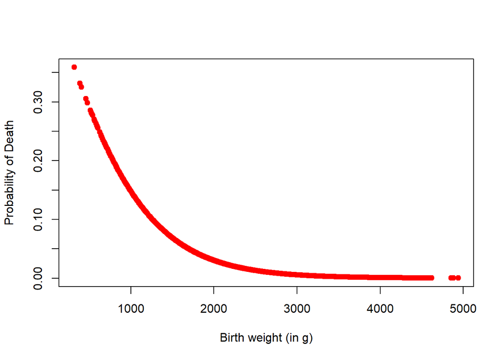

```r
plot(chap10data3$Birthweight,chap10data3.model1$fitted,pch=19,col="red",xlab="Birth weight (in g)",ylab="Probability of Death")
```

## Odds ratios for estimates

```r
exp(chap10data3.model1$coefficients)
```

```
## (Intercept) Birthweight
##   0.9704303   0.9982832
```

```r
exp(confint(chap10data3.model1))
```

```
##                 2.5 %    97.5 %
## (Intercept) 0.5816662 1.6102915
## Birthweight 0.9979638 0.9985859
```

Interpretation: For **each one-unit increase in birthweight**, the **odds of death decrease by a factor of 0.998**. Because the OR is slightly less than 1, **higher birthweight is associated with slightly lower odds of death**.

We are 95% confident that each unit increase in birthweight is associated with a **0.14% - 0.2% decrease in odds of death**. The entire interval is below 1, which is a **statistically significant**

## Goodness-of-fit

```r
anova(chap10data3.model1,test="Chisq")
```

```
## Analysis of Deviance Table
##
## Model: binomial, link: logit
##
## Response: Died
##
## Terms added sequentially (first to last)
##
##
##             Df Deviance Resid. Df Resid. Dev  Pr(>Chi)
## NULL                         2949     926.40
## Birthweight  1   152.68      2948     773.73 < 2.2e-16 ***
## ---
## Signif. codes:  0 '***' 0.001 '**' 0.01 '*' 0.05 '.' 0.1 ' ' 1
```

**Deviance** is a measure of model fit; lower is better.

The **null model** includes no predictors (intercept only). Its deviance is **926.40**.

Adding `Birthweight` reduces the deviance to **773.73**, a drop of **152.68**.

This drop in deviance is tested using a **Chi-squared test**, and the result is **highly significant** (p < 2.2e-16).

**Birthweight is a statistically significant predictor of death.** The model including birthweight fits the data **significantly better** than the null model (no predictors). The very small p-value indicates that this improvement is **not due to chance**.

## Confusion matrix

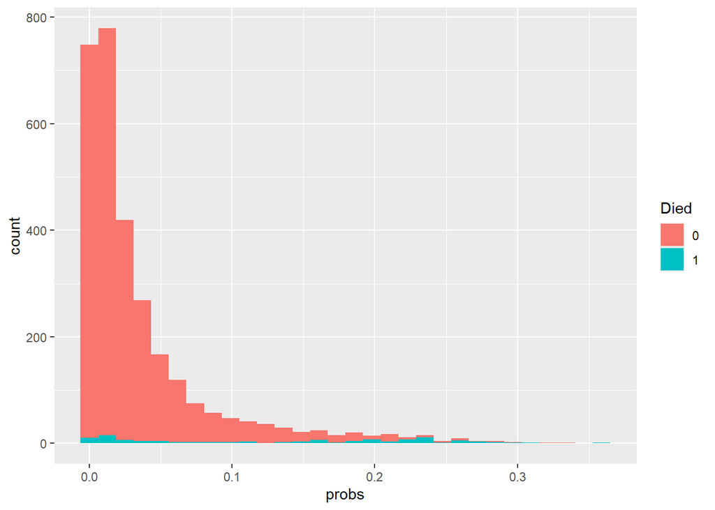

```r
# predict probability
chap10data3$probs <- predict(chap10data3.model1,type="response")
ggplot(chap10data3, aes(x = probs, fill = Died)) +
 geom_histogram()
```

```r
# based on predicted survival probability,
# predict outcome according to cut-off threshold
chap10data3$preds <- ifelse(chap10data3$probs>=0.3,"Yes","No")

# confusion matrix
cm1 <- table(chap10data3[,c("Died","preds")])
cm1
```

```
##     preds
## Died   No  Yes
##    0 2840    2
##    1  106    2
```

```r
#Sensitivity
cm1[2, 2] / sum(cm1[2, ])
```

```
## [1] 0.01851852
```

```r
#Specificity
cm1[1, 1] / sum(cm1[1, ])
```

```
## [1] 0.9992963
```

```r
#Accuracy
sum(diag(cm1)) / sum(cm1)
```

```
## [1] 0.9633898
```

```r
# how about another threshold??
chap10data3$preds2 <- ifelse(chap10data3$probs>=0.05,"Yes","No")

cm2 <- table(chap10data3[,c("Died","preds2")])
cm2
```

```
##     preds2
## Died   No  Yes
##    0 2277  565
##    1   39   69
```

```r
#Sensitivity
cm2[2, 2] / sum(cm2[2, ])
```

```
## [1] 0.6388889
```

```r
#Specificity
cm2[1, 1] / sum(cm2[1, ])
```

```
## [1] 0.8011963
```

```r
#Accuracy
sum(diag(cm2)) / sum(cm2)
```

```
## [1] 0.7952542
```

## Evaluate the performance of the model - ROC curve

```
## A performance instance
##   'Area under the ROC curve'
## Note: The area under the receiver operating characteristic (ROC) curve
## is given at the "y.values" slot in the output above.
```

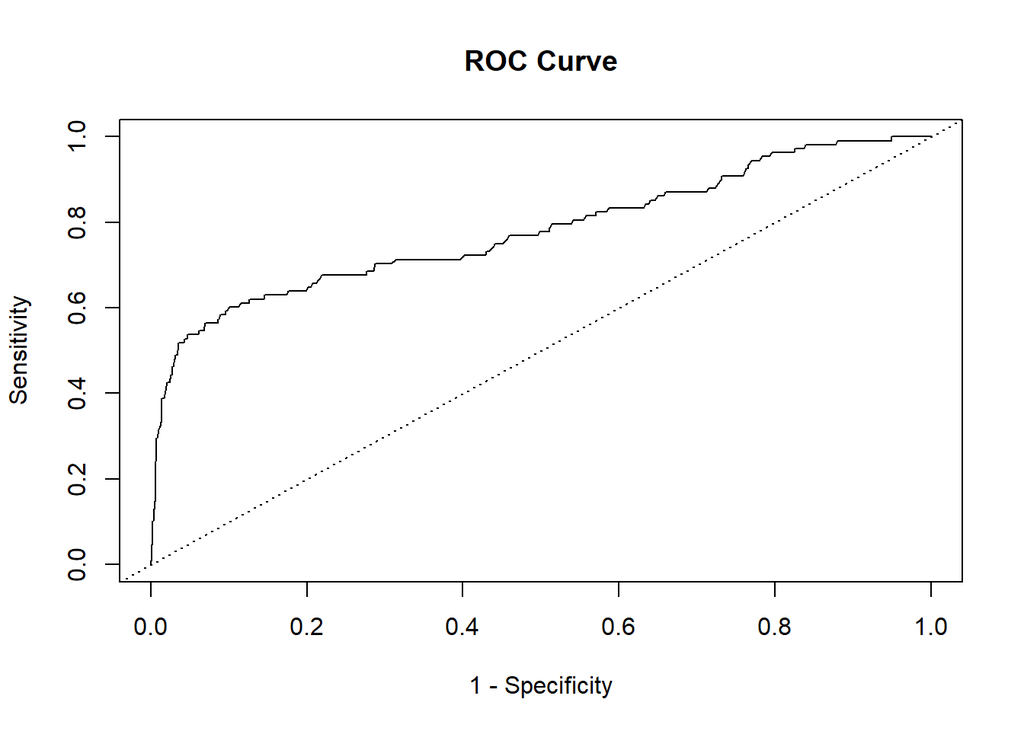

```
##
## Odds ratio estimates for the parameters in the model:
##
## Birthweight
##   0.9982832
```

```r
ROC.curve(chap10data3.model1,response=chap10data3$Died)
```

## Evaluate the performance of the model - gini coefficient

The **Gini coefficient** to evaluates the discriminatory power of a logistic regression model, in this case: predicting death from birthweight.

```r
chap10data3.model1.pr <- predict(chap10data3.model1,type="response",chap10data3.model1$data)

chap10data3.model1.auc <- performance(prediction(chap10data3.model1.pr, chap10data3$Died), "auc")

chap10data3.model1.gini <- abs(1-2*attr(chap10data3.model1.auc,'y.values')[[1]])
chap10data3.model1.gini
```

```
## [1] 0.5589276
```

#### Interpretation

**Gini = 0** → no discriminatory power (like random guessing)

**Gini = 1** → perfect discrimination

**Gini > 0.4** is typically considered **acceptable**

**Gini > 0.6–0.7** is **strong**

# Example 4

## Visualise data

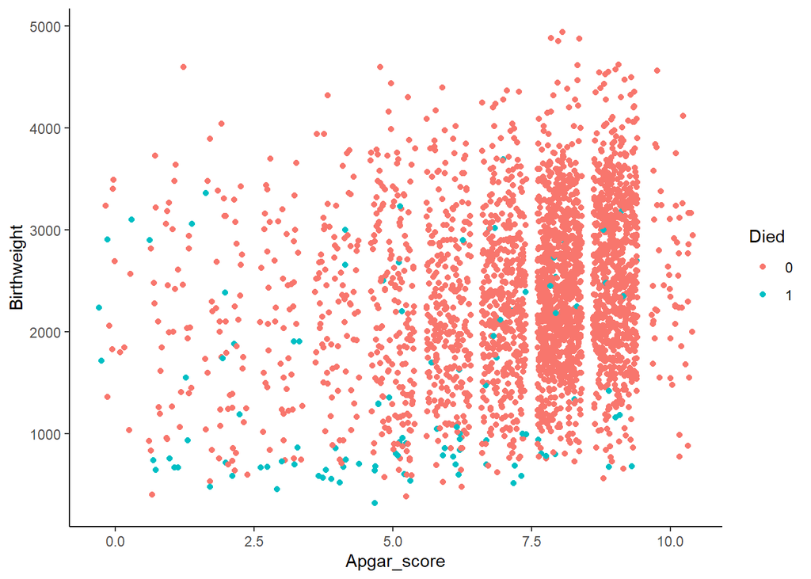

```r
chap10data4 <- read.csv("chap10data4.csv")
chap10data4$Died <- factor(chap10data4$Died, levels = c("No", "Yes"), labels = c(0, 1))
ggplot(chap10data4, aes(x = Apgar_score, y = Birthweight, colour = Died)) +
 geom_jitter() +
 theme_classic()
```

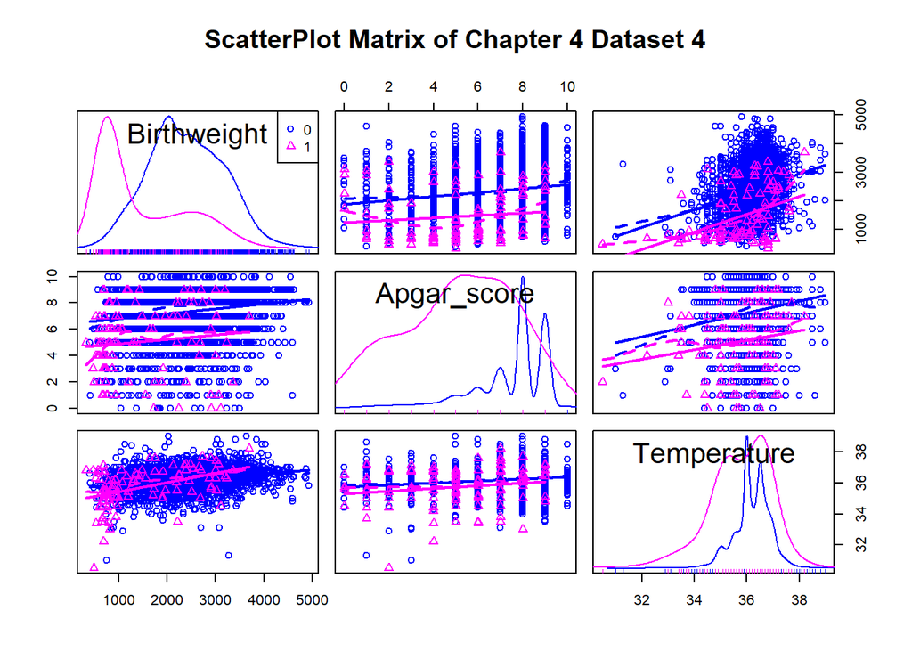

```r
car::scatterplotMatrix(~Birthweight + Apgar_score + Temperature,data=chap10data4,
                  groups=chap10data4$Died,
                  main="ScatterPlot Matrix of Chapter 4 Dataset 4") |> suppressWarnings()
```

## Fit logistic regression model

```r
chap10data4.model1 <- glm(Died ~ ., family=binomial(), data=chap10data4)
summary(chap10data4.model1)
```

```
##
## Call:
## glm(formula = Died ~ ., family = binomial(), data = chap10data4)
##
## Coefficients:
##                        Estimate Std. Error z value Pr(>|z|)
## (Intercept)           4.2274194  4.2326840   0.999 0.317913
## Delivery_modeVaginal  0.9178435  0.2434897   3.770 0.000164 ***
## Birthweight          -0.0013693  0.0001587  -8.627  < 2e-16 ***
## Apgar_score          -0.3000551  0.0430906  -6.963 3.32e-12 ***
## Temperature          -0.0880420  0.1202454  -0.732 0.464055
## ---
## Signif. codes:  0 '***' 0.001 '**' 0.01 '*' 0.05 '.' 0.1 ' ' 1
##
## (Dispersion parameter for binomial family taken to be 1)
##
##     Null deviance: 926.40  on 2949  degrees of freedom
## Residual deviance: 704.83  on 2945  degrees of freedom
## AIC: 714.83
##
## Number of Fisher Scoring iterations: 7
```

## Assess multicollinearity

```r
vif(chap10data4.model1)
```

```
## Delivery_mode   Birthweight   Apgar_score   Temperature
##      1.030095      1.125895      1.067512      1.129552
```

## Variable selection

```r
stepwise(chap10data4.model1,direction="backward/forward",criterion="AIC")
```

```
##
## Direction:  backward/forward
## Criterion:  AIC
##
## Start:  AIC=714.83
## Died ~ Delivery_mode + Birthweight + Apgar_score + Temperature
##
##                 Df Deviance    AIC
## - Temperature    1   705.37 713.37
## <none>               704.83 714.83
## - Delivery_mode  1   717.84 725.84
## - Apgar_score    1   750.33 758.33
## - Birthweight    1   798.87 806.87
##
## Step:  AIC=713.37
## Died ~ Delivery_mode + Birthweight + Apgar_score
##
##                 Df Deviance    AIC
## <none>               705.37 713.37
## + Temperature    1   704.83 714.83
## - Delivery_mode  1   719.40 725.40
## - Apgar_score    1   753.26 759.26
## - Birthweight    1   813.04 819.04
```

```
##
## Call:  glm(formula = Died ~ Delivery_mode + Birthweight + Apgar_score,
##     family = binomial(), data = chap10data4)
##
## Coefficients:
##          (Intercept)  Delivery_modeVaginal           Birthweight
##             1.137263              0.940923             -0.001401
##          Apgar_score
##            -0.304410
##
## Degrees of Freedom: 2949 Total (i.e. Null);  2946 Residual
## Null Deviance:       926.4
## Residual Deviance: 705.4     AIC: 713.4
```

```r
allSubsets.LogistReg(chap10data4,y.name="Died",perf.measure="AIC")
```

```
##                                                       Model              AIC
## 1                                      Died ~ Delivery_mode 914.315704924007
## 2                                        Died ~ Temperature 891.515388066958
## 3                          Died ~ Delivery_mode+Temperature 880.221125547913
## 4                                        Died ~ Apgar_score 825.380326677947
## 5                          Died ~ Delivery_mode+Apgar_score 819.038723944994
## 6                            Died ~ Apgar_score+Temperature 811.079611928887
## 7              Died ~ Delivery_mode+Apgar_score+Temperature 806.873180644797
## 8                                        Died ~ Birthweight 777.726942537111
## 9                            Died ~ Birthweight+Temperature 774.864047472392
## 10                         Died ~ Delivery_mode+Birthweight 759.255101831784
## 11             Died ~ Delivery_mode+Birthweight+Temperature 758.332469037431
## 12               Died ~ Birthweight+Apgar_score+Temperature 725.835159152645
## 13                           Died ~ Birthweight+Apgar_score 725.400962670849
## 14 Died ~ Delivery_mode+Birthweight+Apgar_score+Temperature 714.828756855207
```

[output cut: 17 more lines]

## Fit the final model

```r
chap10data4.model2 <- glm(Died ~ Delivery_mode+Birthweight+Apgar_score, family=binomial(), data=chap10data4)
summary(chap10data4.model2)
```

```
##
## Call:
## glm(formula = Died ~ Delivery_mode + Birthweight + Apgar_score,
##     family = binomial(), data = chap10data4)
##
## Coefficients:
##                        Estimate Std. Error z value Pr(>|z|)
## (Intercept)           1.1372630  0.3232827   3.518 0.000435 ***
## Delivery_modeVaginal  0.9409230  0.2404518   3.913 9.11e-05 ***
## Birthweight          -0.0014009  0.0001533  -9.138  < 2e-16 ***
## Apgar_score          -0.3044104  0.0426201  -7.142 9.17e-13 ***
## ---
## Signif. codes:  0 '***' 0.001 '**' 0.01 '*' 0.05 '.' 0.1 ' ' 1
##
## (Dispersion parameter for binomial family taken to be 1)
##
##     Null deviance: 926.40  on 2949  degrees of freedom
## Residual deviance: 705.37  on 2946  degrees of freedom
## AIC: 713.37
##
## Number of Fisher Scoring iterations: 7
```

## Assess the final model

```
## A performance instance
##   'Area under the ROC curve'
## Note: The area under the receiver operating characteristic (ROC) curve
## is given at the "y.values" slot in the output above.
```

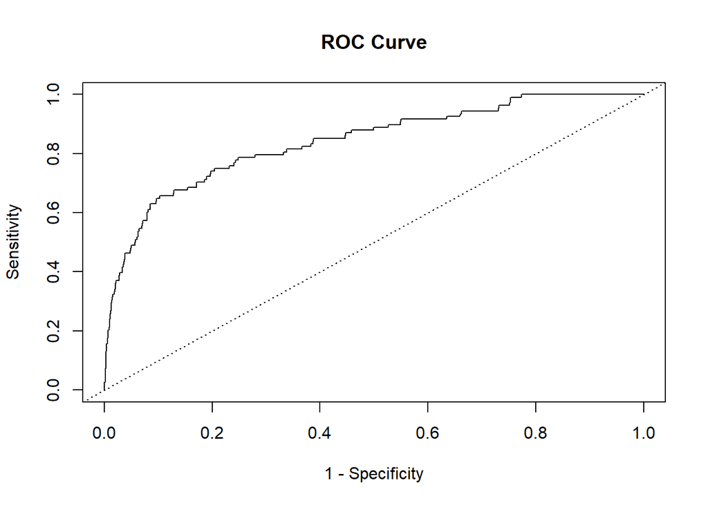

```
##
## Odds ratio estimates for the parameters in the model:
##
## Delivery_modeVaginal          Birthweight          Apgar_score
##            2.5623454            0.9986001            0.7375581
```

```r
ROC.curve(chap10data4.model2,response=chap10data4$Died)
```

```r
calcGini(chap10data4.model2,Y=chap10data4$Died)
```

```
## [1] 0.680448
```

```r
chap10data4$Probs <- predict(chap10data4.model2,type="response")
chap10data4$Preds <- ifelse(chap10data4$Probs>=0.2,"Yes","No")
table(chap10data4$Preds,chap10data4$Died)
```

```
##
##          0    1
##   No  2778   68
##   Yes   64   40
```

```r
mean(chap10data4$Preds!=chap10data4$Died)
```

```
## [1] 1
```

## Predicting with the final model

```r
predict(chap10data4.model2,newdata=data.frame(Delivery_mode="Caesarean",Birthweight=1000,Apgar_score=6),type="response")
```

```
##         1
## 0.1100639
```